# 1. PROBLEM STATEMENT:-

# b. Plotting HDI VS Happiness Score

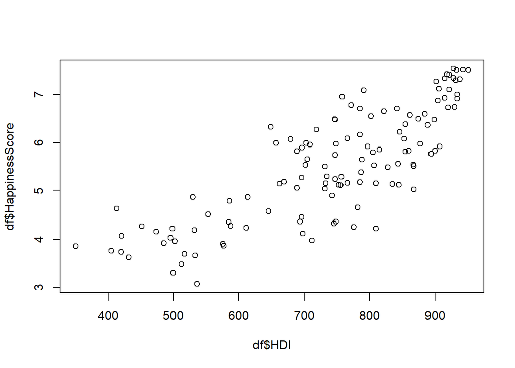

```r
plot(x=df$HDI,y = df$HappinessScore)
```

#Observation: There is a linear trend.. with increase in HDI, happiness score is also increasing.

# c. Plotting Total alcohol consumption Vs HDI

```r
df$total_alcohol <- df$Beer_PerCapita + df$Spirit_PerCapita + df$Wine_PerCapita
View(df)
```

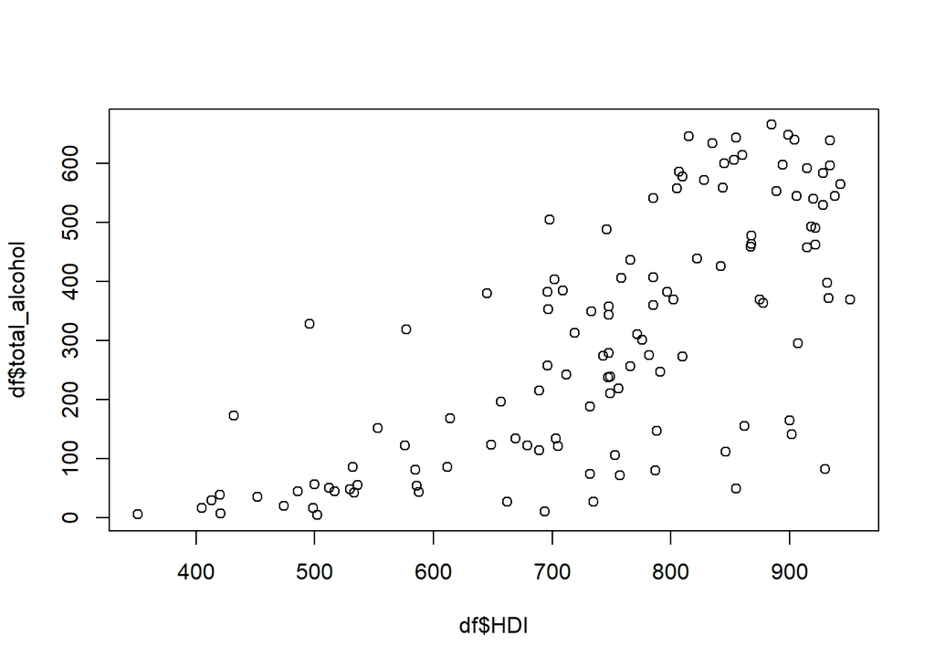

```r
plot(x=df$HDI,y=df$total_alcohol)
```

#Observation: As per the graph, as HDI increases total alcohol consumption seems to be increasing. Which means if life expectancy,literacy rate and standards of living are increasing, the alcohol is consumed more. While in case of Syria, HDI is low so is alcohol consumption. As Syria is an Islamic country it consumes less to no alcohol and also due to on going wars in Syria the HDI, GDP is low. Which makes it hard to compare happiness with alcohol in this particular case.

# d. Plotting Total Alcohol consumption Vs Happiness score

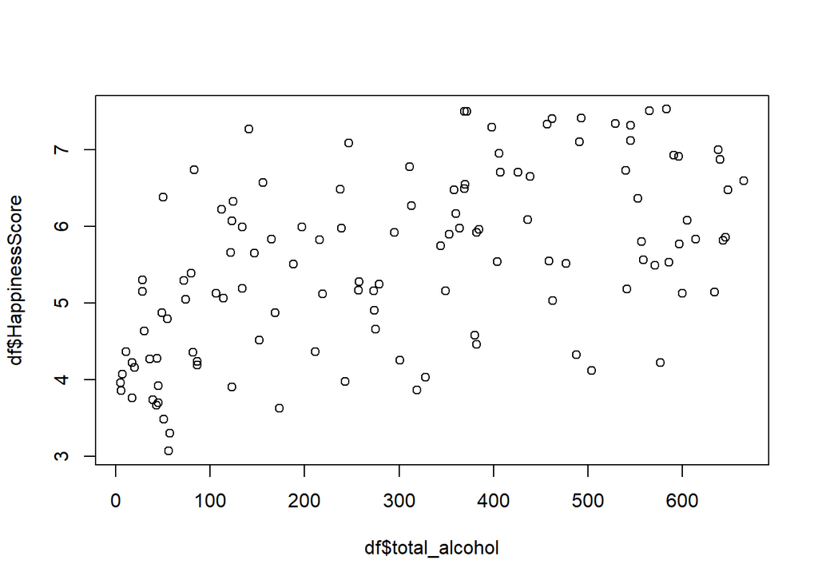

```r
plot(x=df$total_alcohol,y=df$HappinessScore)
```

# e.Plotting side by side box plot

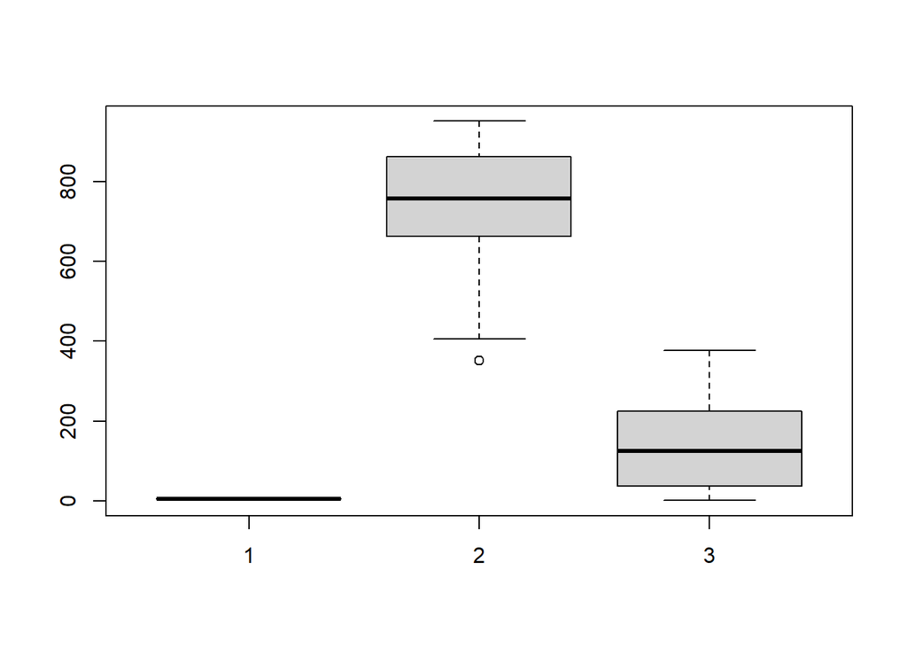

```r
boxplot(df$HappinessScore,df$HDI,df$Beer_PerCapita)
```

# Observation:- Since all three of the variables are on different scales, we cannot infer any results from this. We need to standardize the variables and re-plot them to study their behavior.

#2. Correlation Matrix

```r
df_num = df[,c('HappinessScore','HDI','Beer_PerCapita','Spirit_PerCapita','Wine_PerCapita')]
df_num
```

```
##     HappinessScore HDI Beer_PerCapita Spirit_PerCapita Wine_PerCapita
## 1            7.526 928            224               81            278
## 2            7.509 943            185              100            280
## 3            7.501 933            233               61             78
## 4            7.498 951            169               71            129
## 5            7.413 918            263              133             97
## 6            7.404 922            240              122            100
## 7            7.339 928            251               88            190
## 8            7.334 915            203               79            175
## 9            7.313 938            261               72            212
## 10           7.291 932            152               60            186
## 11           7.267 902             63               69              9
## 12           7.119 906            279               75            191
## 13           7.104 922            249              158             84
## 14           7.087 791            149               87             11
```

[output cut: 108 more lines]

```r
cor_matrix <- cor(df_num)
round(cor_matrix,2)
```

```
##                  HappinessScore  HDI Beer_PerCapita Spirit_PerCapita
## HappinessScore             1.00 0.82           0.49             0.26
## HDI                        0.82 1.00           0.59             0.39
## Beer_PerCapita             0.49 0.59           1.00             0.36
## Spirit_PerCapita           0.26 0.39           0.36             1.00
## Wine_PerCapita             0.45 0.60           0.47             0.12
##                  Wine_PerCapita
## HappinessScore             0.45
## HDI                        0.60
## Beer_PerCapita             0.47
## Spirit_PerCapita           0.12
## Wine_PerCapita             1.00
```

# Observation:

By this there is high positive correlation between HDI and Happiness score. Moving forward we will make our assumptions based on this fact.

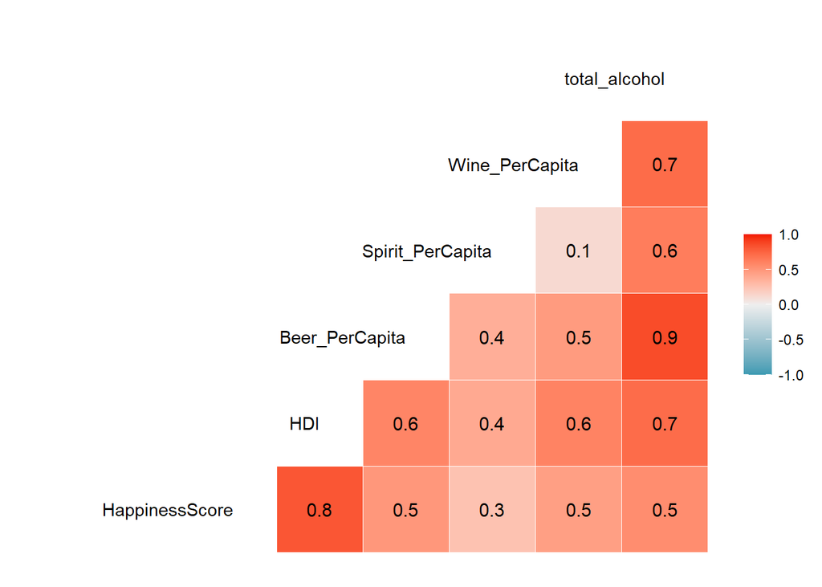

```r
library(GGally)
ggcorr(df,label=T, layout.exp=2, hjust= 1)
```